# AB programación: Dataset de estudiantes

## Explicación del dataset

Diego Romero Puyal.

El dataset ha sido obtenido de la página **Kaggle**: https://www.kaggle.com/. De la sección de datasets, específicamente hemos seleccionado este dataset: https://www.kaggle.com/datasets/lainguyn123/student-performance-factors. Este conjunto de datos ofrece una visión completa de diversos factores que afectan el rendimiento de los estudiantes en los exámenes. Incluye información sobre hábitos de estudio, asistencia, participación de los padres y otros aspectos que influyen en el éxito académico.

# Parte 1: carga y exploración de datos.

Primero cargamos las librerías que usaremos en R

```r
library(readr)
library(skimr)
library(dplyr)
library(esquisse)
library(reshape2)
library(ggplot2)
library(tidyr)
library(gridExtra)
library(moments)
library(caret)
library(reticulate)
```

Luego cargamos las librerías que usaremos en python

```python
reticulate::repl_python()
import pandas as pd
import scipy.stats as stats
from sklearn.model_selection import train_test_split
from sklearn.preprocessing import LabelEncoder, OneHotEncoder, StandardScaler
from sklearn.compose import ColumnTransformer
from sklearn.naive_bayes import CategoricalNB, GaussianNB
from sklearn.pipeline import Pipeline
from sklearn.metrics import accuracy_score, confusion_matrix, classification_report
from imblearn.over_sampling import SMOTE
```

Importamos el dataset y mostramos las 10 primeras filas de nuestro dataset

```r
quit
st <- read_csv("estudiantes.csv", show_col_types = FALSE)
head(st,10, show_col_types = FALSE)
```

| Hours_Studied | Attendance | Parental_Involvement | Access_to_Resources | Extracurricular_Activities | Sleep_Hours | Previous_Scores | Motivation_Level | Internet_Access | Tutoring_Sessions | Family_Income | Teacher_Quality | School_Type | Peer_Influence | Physical_Activity | Learning_Disabilities | Parental_Education_Level | Distance_from_Home | Gender | Exam_Score |
| --- | --- | --- | --- | --- | --- | --- | --- | --- | --- | --- | --- | --- | --- | --- | --- | --- | --- | --- | --- |
| 23 | 84 | Low | High | No | 7 | 73 | Low | Yes | 0 | Low | Medium | Public | Positive | 3 | No | High School | Near | Male | 67 |
| 19 | 64 | Low | Medium | No | 8 | 59 | Low | Yes | 2 | Medium | Medium | Public | Negative | 4 | No | College | Moderate | Female | 61 |
| 24 | 98 | Medium | Medium | Yes | 7 | 91 | Medium | Yes | 2 | Medium | Medium | Public | Neutral | 4 | No | Postgraduate | Near | Male | 74 |
| 29 | 89 | Low | Medium | Yes | 8 | 98 | Medium | Yes | 1 | Medium | Medium | Public | Negative | 4 | No | High School | Moderate | Male | 71 |
| 19 | 92 | Medium | Medium | Yes | 6 | 65 | Medium | Yes | 3 | Medium | High | Public | Neutral | 4 | No | College | Near | Female | 70 |
| 19 | 88 | Medium | Medium | Yes | 8 | 89 | Medium | Yes | 3 | Medium | Medium | Public | Positive | 3 | No | Postgraduate | Near | Male | 71 |
| 29 | 84 | Medium | Low | Yes | 7 | 68 | Low | Yes | 1 | Low | Medium | Private | Neutral | 2 | No | High School | Moderate | Male | 67 |
| 25 | 78 | Low | High | Yes | 6 | 50 | Medium | Yes | 1 | High | High | Public | Negative | 2 | No | High School | Far | Male | 66 |
| 17 | 94 | Medium | High | No | 6 | 80 | High | Yes | 0 | Medium | Low | Private | Neutral | 1 | No | College | Near | Male | 69 |
| 23 | 98 | Medium | Medium | Yes | 8 | 71 | Medium | Yes | 0 | High | High | Public | Positive | 5 | No | High School | Moderate | Male | 72 |

Tras un primer vistazo podemos observar que tenemos 20 columnas y tenemos tanto valores numéricos como no numéricos. Ademas sospechamos que hay bastantes valores categóricos. Vamos a analizarlo mas a fondo.

Separamos las columnas numéricas de las no numéricas para mejor observación de los datos.

```r
numeric_columns <- sapply(st, is.numeric)
```

```r
lapply(st[!numeric_columns], unique)
```

```
$Parental_Involvement
[1] "Low"    "Medium" "High"

$Access_to_Resources
[1] "High"   "Medium" "Low"

$Extracurricular_Activities
[1] "No"  "Yes"

$Motivation_Level
[1] "Low"    "Medium" "High"

$Internet_Access
[1] "Yes" "No"

$Family_Income
[1] "Low"    "Medium" "High"

$Teacher_Quality
[1] "Medium" "High"   "Low"    NA

$School_Type
[1] "Public"  "Private"

$Peer_Influence
[1] "Positive" "Negative" "Neutral"

$Learning_Disabilities
[1] "No"  "Yes"

$Parental_Education_Level
[1] "High School"  "College"      "Postgraduate" NA

$Distance_from_Home
[1] "Near"     "Moderate" "Far"      NA

$Gender
[1] "Male"   "Female"
```

Aquí podemos ver que todos las columnas no numéricas son categóricas. esto lo tendremos en cuenta para el análisis y la limpieza mas adelante.

Ahora buscamos los valores nulos dentro de las columnas.

Usamos `skim` mejor que `summary()` porque da mas información y presentada de forma mas limpia.

```r
skim(st[!numeric_columns])
```

```
── Data Summary ────────────────────────
                           Values
Name                       st[!numeric_columns]
Number of rows             6607
Number of columns          13
_______________________
Column type frequency:
  character                13
________________________
Group variables            None
```

|  | skim_variable | n_missing | complete_rate | min | max | empty | n_unique | whitespace |
| --- | --- | --- | --- | --- | --- | --- | --- | --- |
| 1 | Parental_Involvement | 0 | 1.0000000 | 3 | 6 | 0 | 3 | 0 |
| 2 | Access_to_Resources | 0 | 1.0000000 | 3 | 6 | 0 | 3 | 0 |
| 3 | Extracurricular_Activities | 0 | 1.0000000 | 2 | 3 | 0 | 2 | 0 |
| 4 | Motivation_Level | 0 | 1.0000000 | 3 | 6 | 0 | 3 | 0 |
| 5 | Internet_Access | 0 | 1.0000000 | 2 | 3 | 0 | 2 | 0 |
| 6 | Family_Income | 0 | 1.0000000 | 3 | 6 | 0 | 3 | 0 |
| 7 | Teacher_Quality | 78 | 0.9881943 | 3 | 6 | 0 | 3 | 0 |
| 8 | School_Type | 0 | 1.0000000 | 6 | 7 | 0 | 2 | 0 |
| 9 | Peer_Influence | 0 | 1.0000000 | 7 | 8 | 0 | 3 | 0 |
| 10 | Learning_Disabilities | 0 | 1.0000000 | 2 | 3 | 0 | 2 | 0 |

[output cut: 3 more lines]

Se observa que tenemos valores nulos en 3 columnas: `Teacher_Quality`, `Parental_Educational_Level` y `Distance_From_Home` Mas tarde en la limpieza de datos veremos que hacer con ellos.

```r
skim(st[numeric_columns])
```

```
── Data Summary ────────────────────────
                           Values
Name                       st[numeric_columns]
Number of rows             6607
Number of columns          7
_______________________
Column type frequency:
  numeric                  7
________________________
Group variables            None

── Variable type: numeric ──────────────────────────────────────────────────────────────────────────────────────────────────────────────────────────────────────────────────────────────
  skim_variable     n_missing complete_rate  mean    sd p0 p25 p50 p75 p100 hist
1 Hours_Studied             0             1 20.0   5.99  1  16  20  24   44 ▁▆▇▂▁
2 Attendance                0             1 80.0  11.5  60  70  80  90  100 ▇▇▇▇▇
3 Sleep_Hours               0             1  7.03  1.47  4   6   7   8   10 ▅▆▇▆▅
4 Previous_Scores           0             1 75.1  14.4  50  63  75  88  100 ▇▇▇▇▇
5 Tutoring_Sessions         0             1  1.49  1.23  0   1   1   2    8 ▇▆▁▁▁
6 Physical_Activity         0             1  2.97  1.03  0   2   3   4    6 ▂▅▇▅▁
7 Exam_Score                0             1 67.2   3.89 55  65  67  69  101 ▂▇▁▁▁
```

En los datos numéricos al contrario que pasaba en los no numéricos no tenemos ningún valor nulo.

# Parte 2: Limpieza de datos

Vemos que tenemos valores nulos en 3 columnas:`Parental_Education_Level`, `Teacher_Quality`, `Distance_from_Home`  
Como las 3 columnas que contienen nulos son categóricas vamos a limpiarlas usando la librería `pandas` de python para una mayor facilidad a la hora de trabajar con la moda.

```python
reticulate::repl_python()
df = pd.read_csv("estudiantes.csv")
```

```python
df["Parental_Education_Level"].fillna(df["Parental_Education_Level"].mode()[0], inplace=True)
df["Teacher_Quality"].fillna(df["Teacher_Quality"].mode()[0], inplace=True)
df["Distance_from_Home"].fillna(df["Distance_from_Home"].mode()[0], inplace=True)
```

```python
print(df[["Parental_Education_Level", "Teacher_Quality", "Distance_from_Home"]].isnull().sum())
```

```
Parental_Education_Level    0
Teacher_Quality             0
Distance_from_Home          0
dtype: int64
```

Vemos que hemos eliminado correctamente los valores nulos, tras esto devolvemos el csv limpio y empezaremos a analizarlo y trabajar con el en futuros modelos.

Devolvemos el csv limpio y trabajaremos con él.

```python
df.to_csv("st_clean.csv", index=False)
```

```r
quit
st_clean <- read_csv("st_clean.csv", show_col_types = FALSE)
```

# Parte 3: Análisis de los datos

primero veremos si existe algún tipo de desequilibrio en los datos

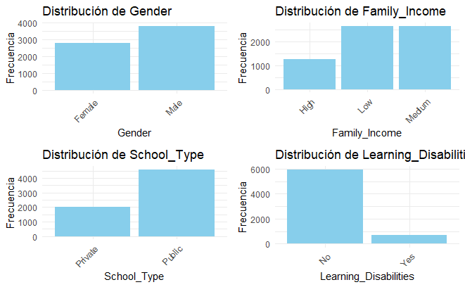

```r
categorical_vars <- c("Gender", "Family_Income", "School_Type", "Learning_Disabilities")

plots <- list()

for (var in categorical_vars) {
  p <- ggplot(st_clean, aes_string(x = var)) +
    geom_bar(fill = "skyblue") +
    theme_minimal() +
    labs(title = paste("Distribución de", var), x = var, y = "Frecuencia") +
    theme(axis.text.x = element_text(angle = 45, hjust = 1))

  plots[[var]] <- p
}
grid.arrange(grobs = plots, nrow = 2, ncol = 2)
```

Sesgo:

## Mapa de correlaciones.

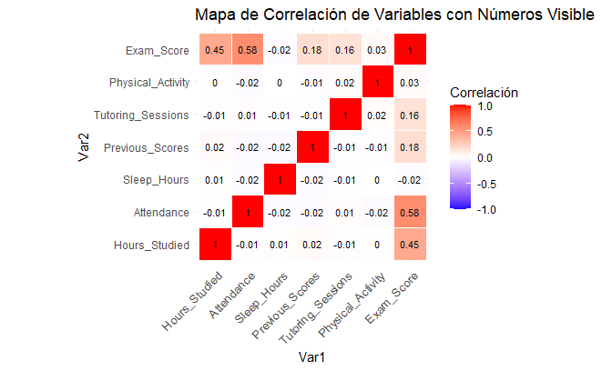

```r
cor_matrix <- cor(st_clean[, sapply(st_clean, is.numeric)], use = "complete.obs")

melted_cor_matrix <- melt(cor_matrix)

ggplot(data = melted_cor_matrix, aes(x = Var1, y = Var2, fill = value)) +
  geom_tile(color = "white") +
  geom_text(aes(label = round(value, 2)), color = "black", size = 3) +
  scale_fill_gradient2(low = "blue", high = "red", mid = "white",
                       midpoint = 0, limit = c(-1, 1), space = "Lab",
                       name = "Correlación") +
  theme_minimal() +
  theme(axis.text.x = element_text(angle = 45, vjust = 1,
                                   size = 10, hjust = 1)) +
  coord_fixed() +
  labs(title = "Mapa de Correlación de Variables con Números Visible")
```

En este mapa de calor Podemos observar en las variables numéricas cuales son las que tienen mas peso con la nota del examen. que en este caso podemos ver que son `Attendance` y `Hours_Studied`.

## Distribución de las notas

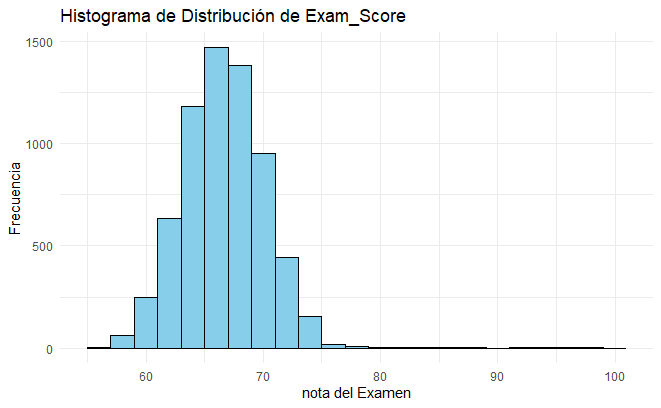

```r
ggplot(st_clean, aes(x = Exam_Score)) +
  geom_histogram(binwidth = 2, fill = "skyblue", color = "black") +
  theme_minimal() +
  labs(title = "Histograma de Distribución de Exam_Score",
       x = "nota del Examen",
       y = "Frecuencia")
```

```r
mediana_exam_score <- median(st_clean$Exam_Score, na.rm = TRUE)
media_exam_score <- mean(st_clean$Exam_Score, na.rm = TRUE)

cat("Mediana de Exam_Score:", mediana_exam_score, "\n")
```

```
Mediana de Exam_Score: 67
```

```r
cat("Media de Exam_Score:", media_exam_score, "\n")
```

```
Media de Exam_Score: 67.23566
```

El histograma da una interpretación visual, pero para concretar más vamos a buscar un valor cuantitativo para ver si estamos en lo cierto. Para ello hacemos el análisis de skewness.

```r
skewness_exam_score <- skewness(st_clean$Exam_Score, na.rm = TRUE)

cat("Coeficiente de asimetría (skewness):", skewness_exam_score, "\n")
```

```
Coeficiente de asimetría (skewness): 1.644435
```

```r
if (abs(skewness_exam_score) < 0.5) {
  cat("La distribución es aproximadamente simétrica.\n")
} else if (skewness_exam_score > 0.5) {
  cat("La distribución está sesgada a la derecha.\n")
} else if (skewness_exam_score < -0.5) {
  cat("La distribución está sesgada a la izquierda.\n")
}
```

```
La distribución está sesgada a la derecha.
```

El coeficiente de asimetría obtenido es **1.644435**, lo que indica que la distribución está sesgada a la derecha. Esto significa que la cola de la distribución es más larga hacia los valores más altos.

## Análisis por género

Vamos a realizar un análisis centrándonos en el género donde veremos si tiene una relevancia en distintas variables como pueden ser:

```
Exam_Score,Previous_Scores, Motivation_Level, Tutoring_Sessions, Hours_Studied, Attendance
```

### Notas según género

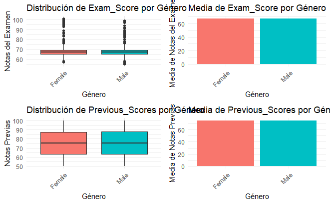

```r
boxplot_exam <- ggplot(st_clean, aes(x = Gender, y = Exam_Score, fill = Gender)) +
  geom_boxplot() +
  theme_minimal() +
  labs(title = "Distribución de Exam_Score por Género",
       x = "Género",
       y = "Notas del Examen") +
  theme(legend.position = "none",
        axis.text.x = element_text(angle = 45, hjust = 1))

barplot_exam <- st_clean %>%
  group_by(Gender) %>%
  summarise(Media_Exam_Score = mean(Exam_Score, na.rm = TRUE)) %>%
  ggplot(aes(x = Gender, y = Media_Exam_Score, fill = Gender)) +
  geom_bar(stat = "identity", position = "dodge") +
  theme_minimal() +
  labs(title = "Media de Exam_Score por Género",
       x = "Género",
       y = "Media de Notas del Examen") +
  theme(legend.position = "none",
        axis.text.x = element_text(angle = 45, hjust = 1))

boxplot_previous <- ggplot(st_clean, aes(x = Gender, y = Previous_Scores, fill = Gender)) +
  geom_boxplot() +
  theme_minimal() +
  labs(title = "Distribución de Previous_Scores por Género",
       x = "Género",
       y = "Notas Previas") +
  theme(legend.position = "none",
        axis.text.x = element_text(angle = 45, hjust = 1))

barplot_previous <- st_clean %>%
  group_by(Gender) %>%
  summarise(Media_Previous_Scores = mean(Previous_Scores, na.rm = TRUE)) %>%
  ggplot(aes(x = Gender, y = Media_Previous_Scores, fill = Gender)) +
  geom_bar(stat = "identity", position = "dodge") +
  theme_minimal() +
  labs(title = "Media de Previous_Scores por Género",
       x = "Género",
       y = "Media de Notas Previas") +
  theme(legend.position = "none",
        axis.text.x = element_text(angle = 45, hjust = 1))

grid.arrange(
  boxplot_exam, barplot_exam,
  boxplot_previous, barplot_previous,
  nrow = 2, ncol = 2
)
```

[figure not shown]

```r
boxplot_exam <- ggplot(st_clean, aes(x = Gender, y = Exam_Score, fill = Gender)) +
  geom_boxplot() +
  theme_minimal() +
  labs(title = "Distribución de Exam_Score por Género",
       x = "Género",
       y = "Notas del Examen") +
  theme(legend.position = "none",
        axis.text.x = element_text(angle = 45, hjust = 1))

barplot_exam <- st_clean %>%
  group_by(Gender) %>%
  summarise(Media_Exam_Score = mean(Exam_Score, na.rm = TRUE)) %>%
  ggplot(aes(x = Gender, y = Media_Exam_Score, fill = Gender)) +
  geom_bar(stat = "identity", position = "dodge") +
  theme_minimal() +
  labs(title = "Media de Exam_Score por Género",
       x = "Género",
       y = "Media de Notas del Examen") +
  theme(legend.position = "none",
        axis.text.x = element_text(angle = 45, hjust = 1))

boxplot_previous <- ggplot(st_clean, aes(x = Gender, y = Previous_Scores, fill = Gender)) +
  geom_boxplot() +
  theme_minimal() +
  labs(title = "Distribución de Previous_Scores por Género",
       x = "Género",
       y = "Notas Previas") +
  theme(legend.position = "none",
        axis.text.x = element_text(angle = 45, hjust = 1))

barplot_previous <- st_clean %>%
  group_by(Gender) %>%
  summarise(Media_Previous_Scores = mean(Previous_Scores, na.rm = TRUE)) %>%
  ggplot(aes(x = Gender, y = Media_Previous_Scores, fill = Gender)) +
  geom_bar(stat = "identity", position = "dodge") +
  theme_minimal() +
  labs(title = "Media de Previous_Scores por Género",
       x = "Género",
       y = "Media de Notas Previas") +
  theme(legend.position = "none",
        axis.text.x = element_text(angle = 45, hjust = 1))

grid.arrange(
  boxplot_exam, barplot_exam,
  boxplot_previous, barplot_previous,
  nrow = 2, ncol = 2
)
```

Tanto chicas y chicas tienen la misma media.

### Motivación, asistencia, horas de estudio y horas de tutoría según género

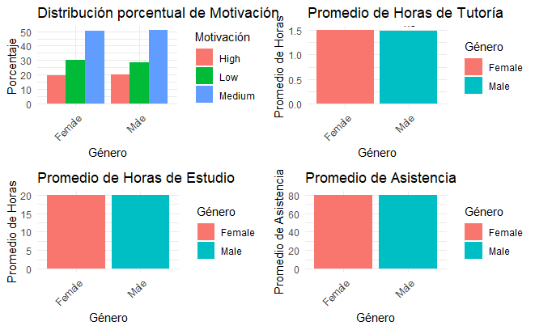

```r
motivacion_por_genero <- st_clean %>%
  group_by(Gender, Motivation_Level) %>%
  summarise(Count = n()) %>%
  mutate(Percentage = Count / sum(Count) * 100) %>%
  ungroup()
grafico_motivacion <- ggplot(motivacion_por_genero, aes(x = Gender, y = Percentage, fill = Motivation_Level)) +
  geom_bar(stat = "identity", position = "dodge") +
  theme_minimal() +
  labs(title = "Distribución porcentual de Motivación",
       x = "Género",
       y = "Porcentaje",
       fill = "Motivación") +
  theme(axis.text.x = element_text(angle = 45, hjust = 1))

promedio_tutoria_por_genero <- st_clean %>%
  group_by(Gender) %>%
  summarise(Promedio_Tutoring_Sessions = mean(Tutoring_Sessions, na.rm = TRUE))

grafico_tutoria <- ggplot(promedio_tutoria_por_genero, aes(x = Gender, y = Promedio_Tutoring_Sessions, fill = Gender)) +
  geom_bar(stat = "identity", position = "dodge") +
  theme_minimal() +
  labs(title = "Promedio de Horas de Tutoría",
       x = "Género",
       y = "Promedio de Horas",
       fill = "Género") +
  geom_text(aes(label = round(Promedio_Tutoring_Sessions, 1)),
            position = position_dodge(width = 0.9),
            vjust = -0.5, size = 3.5) +
  theme(axis.text.x = element_text(angle = 45, hjust = 1))

promedio_estudio_por_genero <- st_clean %>%
  group_by(Gender) %>%
  summarise(Promedio_Study_Hours = mean(Hours_Studied, na.rm = TRUE))

grafico_estudio <- ggplot(promedio_estudio_por_genero, aes(x = Gender, y = Promedio_Study_Hours, fill = Gender)) +
  geom_bar(stat = "identity", position = "dodge") +
  theme_minimal() +
  labs(title = "Promedio de Horas de Estudio",
       x = "Género",
       y = "Promedio de Horas",
       fill = "Género") +
  geom_text(aes(label = round(Promedio_Study_Hours, 1)),
            position = position_dodge(width = 0.9),
            vjust = -0.5, size = 3.5) +
  theme(axis.text.x = element_text(angle = 45, hjust = 1))

promedio_asistencia_por_genero <- st_clean %>%
  group_by(Gender) %>%
  summarise(Promedio_Attendance = mean(Attendance, na.rm = TRUE))

grafico_asistencia <- ggplot(promedio_asistencia_por_genero, aes(x = Gender, y = Promedio_Attendance, fill = Gender)) +
  geom_bar(stat = "identity", position = "dodge") +
  theme_minimal() +
  labs(title = "Promedio de Asistencia",
       x = "Género",
       y = "Promedio de Asistencia",
       fill = "Género") +
  geom_text(aes(label = round(Promedio_Attendance, 1)),
            position = position_dodge(width = 0.9),
            vjust = -0.5, size = 3.5) +
  theme(axis.text.x = element_text(angle = 45, hjust = 1))

grid.arrange(grafico_motivacion, grafico_tutoria, grafico_estudio, grafico_asistencia, nrow = 2, ncol = 2)
```

Se distribuyen de igual manera entre chicos y chicas. El genero no tiene relevancia.

## Análisis según problemas de aprendizaje

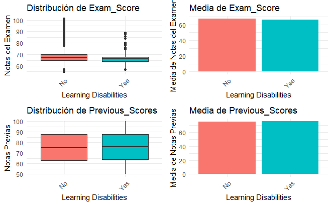

```r
boxplot_exam <- ggplot(st_clean, aes(x = Learning_Disabilities, y = Exam_Score, fill = Learning_Disabilities)) +
  geom_boxplot() +
  theme_minimal() +
  labs(title = "Distribución de Exam_Score",
       x = "Learning Disabilities",
       y = "Notas del Examen") +
  theme(legend.position = "none",
        axis.text.x = element_text(angle = 45, hjust = 1))

barplot_exam <- st_clean %>%
  group_by(Learning_Disabilities) %>%
  summarise(Media_Exam_Score = mean(Exam_Score, na.rm = TRUE)) %>%
  ggplot(aes(x = Learning_Disabilities, y = Media_Exam_Score, fill = Learning_Disabilities)) +
  geom_bar(stat = "identity", position = "dodge") +
  theme_minimal() +
  labs(title = "Media de Exam_Score",
       x = "Learning Disabilities",
       y = "Media de Notas del Examen") +
  theme(legend.position = "none",
        axis.text.x = element_text(angle = 45, hjust = 1))

boxplot_previous <- ggplot(st_clean, aes(x = Learning_Disabilities, y = Previous_Scores, fill = Learning_Disabilities)) +
  geom_boxplot() +
  theme_minimal() +
  labs(title = "Distribución de Previous_Scores",
       x = "Learning Disabilities",
       y = "Notas Previas") +
  theme(legend.position = "none",
        axis.text.x = element_text(angle = 45, hjust = 1))

barplot_previous <- st_clean %>%
  group_by(Learning_Disabilities) %>%
  summarise(Media_Previous_Scores = mean(Previous_Scores, na.rm = TRUE)) %>%
  ggplot(aes(x = Learning_Disabilities, y = Media_Previous_Scores, fill = Learning_Disabilities)) +
  geom_bar(stat = "identity", position = "dodge") +
  theme_minimal() +
  labs(title = "Media de Previous_Scores",
       x = "Learning Disabilities",
       y = "Media de Notas Previas") +
  theme(legend.position = "none",
        axis.text.x = element_text(angle = 45, hjust = 1))

grid.arrange(
  boxplot_exam, barplot_exam,
  boxplot_previous, barplot_previous,
  nrow = 2, ncol = 2
)
```

Podemos ver que la existencia de discapacidades para el aprendizaje no tiene influencia en los resultados de los exámenes.

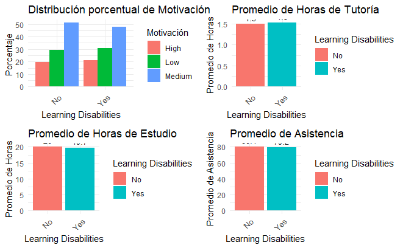

```r
motivacion_por_disabilities <- st_clean %>%
  group_by(Learning_Disabilities, Motivation_Level) %>%
  summarise(Count = n()) %>%
  mutate(Percentage = Count / sum(Count) * 100) %>%
  ungroup()
grafico_motivacion <- ggplot(motivacion_por_disabilities, aes(x = Learning_Disabilities, y = Percentage, fill = Motivation_Level)) +
  geom_bar(stat = "identity", position = "dodge") +
  theme_minimal() +
  labs(title = "Distribución porcentual de Motivación",
       x = "Learning Disabilities",
       y = "Porcentaje",
       fill = "Motivación") +
  theme(axis.text.x = element_text(angle = 45, hjust = 1))

promedio_tutoria_por_disabilities <- st_clean %>%
  group_by(Learning_Disabilities) %>%
  summarise(Promedio_Tutoring_Sessions = mean(Tutoring_Sessions, na.rm = TRUE))

grafico_tutoria <- ggplot(promedio_tutoria_por_disabilities, aes(x = Learning_Disabilities, y = Promedio_Tutoring_Sessions, fill = Learning_Disabilities)) +
  geom_bar(stat = "identity", position = "dodge") +
  theme_minimal() +
  labs(title = "Promedio de Horas de Tutoría",
       x = "Learning Disabilities",
       y = "Promedio de Horas",
       fill = "Learning Disabilities") +
  geom_text(aes(label = round(Promedio_Tutoring_Sessions, 1)),
            position = position_dodge(width = 0.9),
            vjust = -0.5, size = 3.5) +
  theme(axis.text.x = element_text(angle = 45, hjust = 1))

promedio_estudio_por_disabilities <- st_clean %>%
  group_by(Learning_Disabilities) %>%
  summarise(Promedio_Study_Hours = mean(Hours_Studied, na.rm = TRUE))

grafico_estudio <- ggplot(promedio_estudio_por_disabilities, aes(x = Learning_Disabilities, y = Promedio_Study_Hours, fill = Learning_Disabilities)) +
  geom_bar(stat = "identity", position = "dodge") +
  theme_minimal() +
  labs(title = "Promedio de Horas de Estudio",
       x = "Learning Disabilities",
       y = "Promedio de Horas",
       fill = "Learning Disabilities") +
  geom_text(aes(label = round(Promedio_Study_Hours, 1)),
            position = position_dodge(width = 0.9),
            vjust = -0.5, size = 3.5) +
  theme(axis.text.x = element_text(angle = 45, hjust = 1))

promedio_asistencia_por_disabilities <- st_clean %>%
  group_by(Learning_Disabilities) %>%
  summarise(Promedio_Attendance = mean(Attendance, na.rm = TRUE))

grafico_asistencia <- ggplot(promedio_asistencia_por_disabilities, aes(x = Learning_Disabilities, y = Promedio_Attendance, fill = Learning_Disabilities)) +
  geom_bar(stat = "identity", position = "dodge") +
  theme_minimal() +
  labs(title = "Promedio de Asistencia",
       x = "Learning Disabilities",
       y = "Promedio de Asistencia",
       fill = "Learning Disabilities") +
  geom_text(aes(label = round(Promedio_Attendance, 1)),
            position = position_dodge(width = 0.9),
            vjust = -0.5, size = 3.5) +
  theme(axis.text.x = element_text(angle = 45, hjust = 1))

grid.arrange(grafico_motivacion, grafico_tutoria, grafico_estudio, grafico_asistencia, nrow = 2, ncol = 2)
```

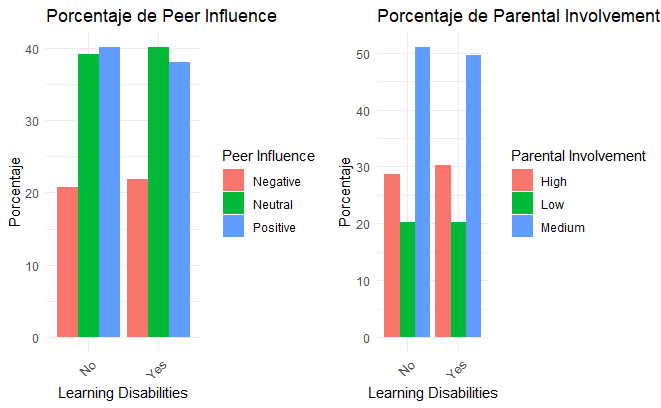

```r
grafico_peer_influence <- st_clean %>%
  group_by(Learning_Disabilities, Peer_Influence) %>%
  summarise(Count = n()) %>%
  mutate(Percentage = Count / sum(Count) * 100) %>%
  ggplot(aes(x = Learning_Disabilities, y = Percentage, fill = Peer_Influence)) +
  geom_bar(stat = "identity", position = "dodge") +
  theme_minimal() +
  labs(title = "Porcentaje de Peer Influence",
       x = "Learning Disabilities",
       y = "Porcentaje",
       fill = "Peer Influence") +
  theme(axis.text.x = element_text(angle = 45, hjust = 1))
grafico_parental_involvement <- st_clean %>%
  group_by(Learning_Disabilities, Parental_Involvement) %>%
  summarise(Count = n()) %>%
  mutate(Percentage = Count / sum(Count) * 100) %>%
  ggplot(aes(x = Learning_Disabilities, y = Percentage, fill = Parental_Involvement)) +
  geom_bar(stat = "identity", position = "dodge") +
  theme_minimal() +
  labs(title = "Porcentaje de Parental Involvement",
       x = "Learning Disabilities",
       y = "Porcentaje",
       fill = "Parental Involvement") +
  theme(axis.text.x = element_text(angle = 45, hjust = 1))
grid.arrange(grafico_peer_influence, grafico_parental_involvement, nrow = 1, ncol = 2)
```

```r
NA
NA
```

No hay grandes diferencias entre tener o no tener problemas de aprendizaje